# Economic and Health Impact from Storms in Kansas, USA

Kevin Rojas Bohorquez

September 2, 2020

## Data Processing

From the [NOAA](https://www.ncdc.noaa.gov/stormevents/) we obtained its [Storm Database](https://www.ncdc.noaa.gov/stormevents/ftp.jsp) where we can find all the major storms and weather events in the United States.

### Reading the Data:

We first read the data with *read.csv* (this function allows us unzip the file without any problem) with its default parameters.

```r
stormUSA<-read.csv("repdata_data_StormData.csv.bz2")
```

After reading in the data, we check the first few rows (there are 902,297) rows in this dataset.

```r
dim(stormUSA)
```

```
## [1] 902297     37
```

```r
head(stormUSA[,1:8])
```

```
##   STATE__           BGN_DATE BGN_TIME TIME_ZONE COUNTY COUNTYNAME STATE  EVTYPE
## 1       1  4/18/1950 0:00:00     0130       CST     97     MOBILE    AL TORNADO
## 2       1  4/18/1950 0:00:00     0145       CST      3    BALDWIN    AL TORNADO
## 3       1  2/20/1951 0:00:00     1600       CST     57    FAYETTE    AL TORNADO
## 4       1   6/8/1951 0:00:00     0900       CST     89    MADISON    AL TORNADO
## 5       1 11/15/1951 0:00:00     1500       CST     43    CULLMAN    AL TORNADO
## 6       1 11/15/1951 0:00:00     2000       CST     77 LAUDERDALE    AL TORNADO
```

### Processing the Data:

We proceed to clean the data and we need these libraries:

```r
library("dplyr")
library("stringr")
```

First we transform the column BGN_DATE to *Date*, then we filter it from 1996, later we select the columns we need for the analysis and finally we get the rows with PROPDMG or CROPDMG more than zero.

```r
stormUSA$BGN_DATE<-as.Date(stormUSA$BGN_DATE, format = "%m/%d/%Y")
stormUSA1996up <-stormUSA %>% filter(BGN_DATE>='1996-01-01') %>%
select(EVTYPE,STATE,FATALITIES,INJURIES,PROPDMG,CROPDMG,PROPDMGEXP,CROPDMGEXP) %>%
  filter(PROPDMG>0 | CROPDMG>0)
```

We detect that column *EVTYPE* has some values different from the [Documentation](https://d396qusza40orc.cloudfront.net/repdata%2Fpeer2_doc%2Fpd01016005curr.pdf). There must be up to 48 types, but there are 186.

```r
length(unique(stormUSA1996up$EVTYPE))
```

```
## [1] 186
```

First, we proceed to erase all the spaces in the column and uppercase it. Then following the documentation, we change the values with its accurate type.

```r
stormUSA1996up$EVTYPE<-(str_squish(toupper(stormUSA1996up$EVTYPE)))

## COASTAL FLOOD
stormUSA1996up[grep("COASTAL FLOOD",stormUSA1996up$EVTYPE),]$EVTYPE="COASTAL FLOOD"
stormUSA1996up[grep("CSTL FLOOD",stormUSA1996up$EVTYPE),]$EVTYPE="COASTAL FLOOD"
stormUSA1996up[grep("COASTAL EROSION",stormUSA1996up$EVTYPE),]$EVTYPE="COASTAL FLOOD"

## COLD/WIND CHILL
stormUSA1996up[grep("COLD$",stormUSA1996up$EVTYPE),]$EVTYPE="COLD/WIND CHILL"

## DEBRIS FLOW
stormUSA1996up[grep("LANDSLIDE",stormUSA1996up$EVTYPE),]$EVTYPE="DEBRIS FLOW"
stormUSA1996up[grep("LANDSLUMP",stormUSA1996up$EVTYPE),]$EVTYPE="DEBRIS FLOW"

## DENSE FOG
stormUSA1996up[grep("^FOG",stormUSA1996up$EVTYPE),]$EVTYPE="DENSE FOG"

## DUST STORM
stormUSA1996up[grep("BLOWING DUST",stormUSA1996up$EVTYPE),]$EVTYPE="DUST STORM"

## EXTREME COLD/WIND CHILL
stormUSA1996up[grep("EXTREME",stormUSA1996up$EVTYPE),]$EVTYPE="EXTREME COLD/WIND CHILL"

## FLASH FLOOD
stormUSA1996up[grep("JAM",stormUSA1996up$EVTYPE),]$EVTYPE="FLASH FLOOD"
stormUSA1996up[grep("MUD",stormUSA1996up$EVTYPE),]$EVTYPE="FLASH FLOOD"
stormUSA1996up[grep("ROCK",stormUSA1996up$EVTYPE),]$EVTYPE="FLASH FLOOD"
stormUSA1996up[grep("DAM ",stormUSA1996up$EVTYPE),]$EVTYPE="FLASH FLOOD"
stormUSA1996up[grep("RIVER FLOOD",stormUSA1996up$EVTYPE),]$EVTYPE="FLASH FLOOD"

## FLOOD
stormUSA1996up[grep("/FLOOD",stormUSA1996up$EVTYPE),]$EVTYPE="FLOOD"
stormUSA1996up[grep("TIDAL FLOOD",stormUSA1996up$EVTYPE),]$EVTYPE="FLOOD"

## FREEZING FOG
stormUSA1996up[grep("GLAZE",stormUSA1996up$EVTYPE),]$EVTYPE="FREEZING FOG"

## FROST/FREEZE
stormUSA1996up[grep("FREEZE",stormUSA1996up$EVTYPE),]$EVTYPE="FROST/FREEZE"
stormUSA1996up[grep("FROST",stormUSA1996up$EVTYPE),]$EVTYPE="FROST/FREEZE"

## HAIL
stormUSA1996up[grep("SMALL HAIL",stormUSA1996up$EVTYPE),]$EVTYPE="HAIL"

## HEAT
stormUSA1996up[grep("UNSEASONABLY WARM",stormUSA1996up$EVTYPE),]$EVTYPE="HEAT"

## HEAVY RAIN
stormUSA1996up[grep("STREAM",stormUSA1996up$EVTYPE),]$EVTYPE="HEAVY RAIN"
stormUSA1996up[grep("^RAIN$",stormUSA1996up$EVTYPE),]$EVTYPE="HEAVY RAIN"
stormUSA1996up[grep("UNSEASONAL RAIN$",stormUSA1996up$EVTYPE),]$EVTYPE="HEAVY RAIN"

## HEAVY SNOW
stormUSA1996up[grep("EXCESSIVE SNOW",stormUSA1996up$EVTYPE),]$EVTYPE="HEAVY SNOW"

## HIGH SURF
stormUSA1996up[grep("SURF",stormUSA1996up$EVTYPE),]$EVTYPE="HIGH SURF"
stormUSA1996up[grep("BEACH EROSION",stormUSA1996up$EVTYPE),]$EVTYPE="HIGH SURF"
stormUSA1996up[grep("HIGH SWELLS",stormUSA1996up$EVTYPE),]$EVTYPE="HIGH SURF"
stormUSA1996up[grep("ASTRONOMICAL HIGH TIDE",stormUSA1996up$EVTYPE),]$EVTYPE="HIGH SURF"
stormUSA1996up[grep("HIGH SEAS",stormUSA1996up$EVTYPE),]$EVTYPE="HIGH SURF"
stormUSA1996up[grep("MARINE ACCIDENT",stormUSA1996up$EVTYPE),]$EVTYPE="HIGH SURF"
stormUSA1996up[grep("WIND AND WAVE",stormUSA1996up$EVTYPE),]$EVTYPE="HIGH SURF"

## HIGH WIND
stormUSA1996up[grep("^HIGH WIND",stormUSA1996up$EVTYPE),]$EVTYPE="HIGH WIND"
stormUSA1996up[grep("NON-SEVERE WIND DAMAGE",stormUSA1996up$EVTYPE),]$EVTYPE="HIGH WIND"

## HURRICANE (TYPHOON)
stormUSA1996up[grep("HURRICANE",stormUSA1996up$EVTYPE),]$EVTYPE="HURRICANE (TYPHOON)"
stormUSA1996up[grep("TYPHOON",stormUSA1996up$EVTYPE),]$EVTYPE="HURRICANE (TYPHOON)"

## LAKE-EFFECT SNOW
stormUSA1996up[grep("LAKE EFFECT",stormUSA1996up$EVTYPE),]$EVTYPE="LAKE-EFFECT SNOW"
stormUSA1996up[grep("SNOW SHOWER",stormUSA1996up$EVTYPE),]$EVTYPE="LAKE-EFFECT SNOW"

## RIP CURRENT
stormUSA1996up[grep("RIP CURRENT",stormUSA1996up$EVTYPE),]$EVTYPE="RIP CURRENT"

## STORM SURGE/TIDE
stormUSA1996up[grep("STORM SURGE",stormUSA1996up$EVTYPE),]$EVTYPE="STORM SURGE/TIDE"

## STRONG WIND
stormUSA1996up[grep("STRONG WINDS",stormUSA1996up$EVTYPE),]$EVTYPE="STRONG WIND"
stormUSA1996up[grep("GUSTY WIND",stormUSA1996up$EVTYPE),]$EVTYPE="STRONG WIND"
stormUSA1996up[grep("^WIND DAMAGE",stormUSA1996up$EVTYPE),]$EVTYPE="STRONG WIND"
stormUSA1996up[grep("^WIND$",stormUSA1996up$EVTYPE),]$EVTYPE="STRONG WIND"

## THUNDERSTORM WIND
stormUSA1996up[grep("BURST",stormUSA1996up$EVTYPE),]$EVTYPE="THUNDERSTORM WIND"
stormUSA1996up$EVTYPE<-sub("TSTM","THUNDERSTORM",stormUSA1996up$EVTYPE)
stormUSA1996up[grep("THUNDERSTORM WIND ",stormUSA1996up$EVTYPE),]$EVTYPE="THUNDERSTORM WIND"
stormUSA1996up[grep("WHIRLWIND",stormUSA1996up$EVTYPE),]$EVTYPE="THUNDERSTORM WIND"
stormUSA1996up[grep("THUNDERSTORM WIND/HAIL",stormUSA1996up$EVTYPE),]$EVTYPE="THUNDERSTORM WIND"

## TORNADO
stormUSA1996up[grep("LANDSPOUT",stormUSA1996up$EVTYPE),]$EVTYPE="TORNADO"

## TROPICAL DEPRESSION
stormUSA1996up[grep("GRADIENT WIND",stormUSA1996up$EVTYPE),]$EVTYPE="TROPICAL DEPRESSION"

## TROPICAL STORM
stormUSA1996up[grep("COASTAL STORM",stormUSA1996up$EVTYPE),]$EVTYPE="TROPICAL STORM"

## WILDFIRE
stormUSA1996up[grep("FOREST",stormUSA1996up$EVTYPE),]$EVTYPE="WILDFIRE"

## WINTER WEATHER
stormUSA1996up[grep("WINTER WEATHER",stormUSA1996up$EVTYPE),]$EVTYPE="WINTER WEATHER"
stormUSA1996up[grep("FREEZING RAIN",stormUSA1996up$EVTYPE),]$EVTYPE="WINTER WEATHER"
stormUSA1996up[grep("DRIZZLE",stormUSA1996up$EVTYPE),]$EVTYPE="WINTER WEATHER"
stormUSA1996up[grep("SQUALL",stormUSA1996up$EVTYPE),]$EVTYPE="WINTER WEATHER"
stormUSA1996up[grep("LIGHT ",stormUSA1996up$EVTYPE),]$EVTYPE="WINTER WEATHER"
stormUSA1996up[grep("BLOWING SNOW",stormUSA1996up$EVTYPE),]$EVTYPE="WINTER WEATHER"
stormUSA1996up[grep("^SNOW",stormUSA1996up$EVTYPE),]$EVTYPE="WINTER WEATHER"
stormUSA1996up[grep("LATE SEASON SNOW",stormUSA1996up$EVTYPE),]$EVTYPE="WINTER WEATHER"
stormUSA1996up[grep("ROADS",stormUSA1996up$EVTYPE),]$EVTYPE="WINTER WEATHER"
stormUSA1996up[grep("WINTRY MIX",stormUSA1996up$EVTYPE),]$EVTYPE="WINTER WEATHER"
stormUSA1996up[grep("MIXED PRECIPITATION",stormUSA1996up$EVTYPE),]$EVTYPE="WINTER WEATHER"
```

Finally, we transform the column EVTYPE into factor type and then we select only the state of Kansas(KS).

```r
stormUSA1996up$EVTYPE<-as.factor(stormUSA1996up$EVTYPE)
stormKS <-stormUSA1996up %>% filter(STATE=="KS")
```

Now, we proceed to calculate the amounts with *PROPDMG* and *CROPDMG* with their units *PROPDMGEXP* and *CROPDMGEXP*. First, we clean the units by uppercasing them and blanking all the values that have 0 damage in *PROPDMG* and *CROPDMG*. Then we transform them into factors.

```r
stormKS<-stormKS%>% mutate(PROPDMGEXP=(toupper(PROPDMGEXP)),CROPDMGEXP=(toupper(CROPDMGEXP))) %>%
mutate(PROPDMGEXP=ifelse(PROPDMG==0,"",PROPDMGEXP),CROPDMGEXP=ifelse(CROPDMG==0,"",CROPDMGEXP)) %>%
mutate(PROPDMGEXP=as.factor(PROPDMGEXP),CROPDMGEXP=as.factor(CROPDMGEXP))
levels(stormKS$PROPDMGEXP)
```

```
## [1] ""  "K" "M"
```

```r
levels(stormKS$CROPDMGEXP)
```

```
## [1] ""  "K" "M"
```

After we valide the units are correct, we use them in order to get the real value of damaged into K(1000) and sum the result in order to get the total economic damage.

```r
stormKS<-stormKS%>% mutate(PROP_K=PROPDMG*case_when(PROPDMGEXP=="K"~1,PROPDMGEXP=="M"~1000,PROPDMGEXP=="B"~1000000,TRUE~0)) %>%
mutate(CROP_K=CROPDMG*case_when(CROPDMGEXP=="K"~1,CROPDMGEXP=="M"~1000,CROPDMGEXP=="B"~1000000,TRUE~0)) %>%
mutate(TOTALDAMAGE_K=PROP_K+CROP_K) %>% select(EVTYPE,STATE,FATALITIES,INJURIES,TOTALDAMAGE_K)
head(stormKS)
```

```
##              EVTYPE STATE FATALITIES INJURIES TOTALDAMAGE_K
## 1      WINTER STORM    KS          1        1             8
## 2         LIGHTNING    KS          0        0             1
## 3 THUNDERSTORM WIND    KS          0        0           250
## 4 THUNDERSTORM WIND    KS          0        0            15
## 5 THUNDERSTORM WIND    KS          0        0            12
## 6              HAIL    KS          0        0             5
```

## Results

### The Most Harmful to Population Health

In order to get the most harmful to Population Health, we are going to use the mean of fatalities and injures per type. First, we calculate the sum and the count per type in order to get mean and then, we order them by the mean of fatalities and create a barplot with the results.

```r
stormKS_health<-stormKS  %>% group_by(EVTYPE) %>%
  summarize(TOTAL_INJURIES=sum(INJURIES),TOTAL_FATALITIES=sum(FATALITIES),count=n(),.groups='drop') %>%
  mutate(mean_fat=TOTAL_FATALITIES/count,mean_inj=TOTAL_INJURIES/count) %>%
  arrange(desc(mean_fat)) %>% slice(1:5)

head(stormKS_health)
```

```
## # A tibble: 5 x 6
##   EVTYPE       TOTAL_INJURIES TOTAL_FATALITIES count mean_fat mean_inj
##   <fct>                 <dbl>            <dbl> <int>    <dbl>    <dbl>
## 1 HEAVY SNOW               17                9    23    0.391    0.739
## 2 FREEZING FOG              4                1     3    0.333    1.33
## 3 DENSE FOG                 9                1     4    0.25     2.25
## 4 WINTER STORM              5                4    39    0.103    0.128
## 5 BLIZZARD                 10                1    10    0.1      1
```

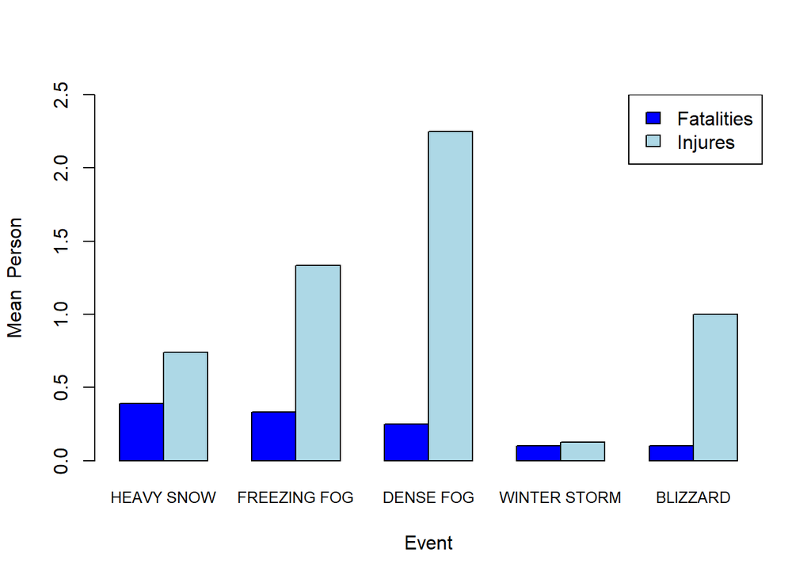

```r
fat_inj<-t(as.vector(stormKS_health[,c("mean_fat","mean_inj")]))
colnames(fat_inj)<-as.vector(stormKS_health$EVTYPE)
barplot(fat_inj,col = c("blue","lightblue"),xlab = "Event",
        ylab = "Mean  Person",ylim=c(0,2.5),beside=TRUE,cex.names=0.8)
legend("topright", c("Fatalities","Injures"),
       fill = c("blue","lightblue"))
```

As we can see in the column *count*, *Freezing Fog* and *Dense Fog* are not common events in Kansas. Thus, we should focus more in *Heavy Snow* as most harmful to population health in Kansas.

### Event with The Greatest Economic Consequences

In order to get the event with the greatest economic consequences, we are going to use the mean of total economic damage per type. First, we calculate the sum and the count per type in order to get mean and then, we order them by the mean of total economic damage and we create a barplot with the results.

```r
stormKS_eco<-stormKS  %>% group_by(EVTYPE) %>%
  summarize(TOTALDAMAGE_K=sum(TOTALDAMAGE_K),count=n(),.groups = 'drop') %>%
  mutate(prom=TOTALDAMAGE_K/count) %>% arrange(desc(prom)) %>% slice(1:5)

head(stormKS_eco)
```

```
## # A tibble: 5 x 4
##   EVTYPE       TOTALDAMAGE_K count   prom
##   <fct>                <dbl> <int>  <dbl>
## 1 DROUGHT            155954      8 19494.
## 2 ICE STORM          183385     33  5557.
## 3 WINTER STORM       107275     39  2751.
## 4 TORNADO            741530.   436  1701.
## 5 FROST/FREEZE         4265      3  1422.
```

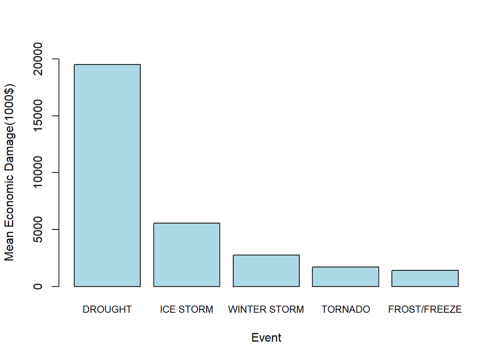

```r
econo<-t(as.vector(stormKS_eco$prom))
colnames(econo)<-as.vector(stormKS_eco$EVTYPE)
barplot(econo,col = c("lightblue"),xlab = "Event",
        ylab = "Mean Economic Damage(1000$)",ylim=c(0,20000),
        cex.names=0.8)
```

It is very clear the *Drought* is by far the one which has the greatest economic Consequences in Kansas.